# unit 3 homework - Phillip Hale

Phillip Hale

May 27, 2019

## Data Summary

> 2. Data Summary (20 points): From this aforementioned cloned repo, please extract titanic.csv.zip. To be clear, this does not have to be done in Git or command line.

```r
library(readr)
df = read_csv("Datasets/titanic.csv/titanic.csv")
names(df)
```

```
##  [1] "PassengerId" "Survived"    "Pclass"      "Name"        "Sex"
##  [6] "Age"         "SibSp"       "Parch"       "Ticket"      "Fare"
## [11] "Cabin"       "Embarked"
```

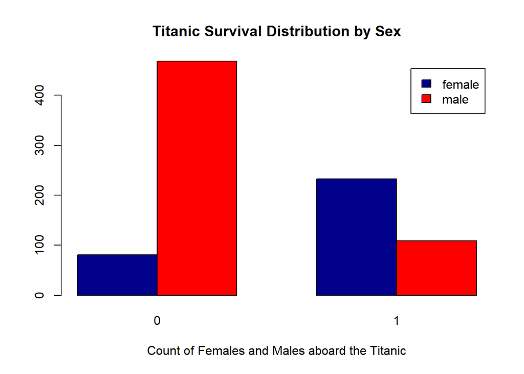

```r
counts = table(df$Sex, df$Survived)
barplot(counts, main="Titanic Survival Distribution by Sex",
  xlab="Count of Females and Males aboard the Titanic", col=c("darkblue","red"),
  legend = rownames(counts), beside=TRUE)
```

> 3. Please use one apply function (to review: swirl() modules 11, 12) to output the means of Age, Fare, and Survival. Make sure the output is a real number for all three means.

```r
apply(na.omit(df[,c("Age", "Fare", "Survived")]), 2, mean)
```

```
##        Age       Fare   Survived
## 29.6991176 34.6945140  0.4061625
```

# 3. Function Building (30 points):

> You research sleep and just got your first data set. Later, you’ll have another dataset with the same column names, so you want to create a helper function that you can analyze this dataset and the next. Load sleep_data_01.csv (found at http://talklab.psy.gla.ac.uk/L1_labs/lab_1/homework/index.html). Questions 3A through 3D should be answered in function(x){}. 3E can be outside of the function.

```r
sleep = read_csv("http://talklab.psy.gla.ac.uk/L1_labs/lab_1/homework/sleep_data_01.csv")
names(sleep)
```

```
##  [1] "SubjID"   "Age"      "Gender"   "PSQI"     "PSAScog"  "FOMO"
##  [7] "SMUISa"   "SM1"      "SM2"      "HADSa"    "HADSd"    "RSES"
## [13] "Bedtime"  "Latency"  "Duration"
```

> 1. Create objects for the median Age, the minimum and maximum Duration of sleep, and the mean and standard deviation of the Rosenberg Self Esteem scale (RSES). You may need to specify a few options like in Problem 2 and live session.

```r
lapply(df, function(x) mean(x, na.rm=T))
```

[output not shown]

```r
prob3 = function(){
  median_sleep = median(sleep$Age,na.rm =TRUE)
  print("Mediaun Age: d% ",median_sleep)


}

prob3()
```

```
## [1] "Mediaun Age: d% "
```

```r
mysummary = function(){

  #a.   Create objects
  median_age = median(sleep$Age,na.rm =TRUE)
  RSES_mean = mean(sleep$RSES, na.rm=T)
  std = sd(sleep$RSES/5, na.rm=T)
  duration_range = range(sleep$Duration, na.rm=T)[2]-range(sleep$Duration, na.rm=T)[1]

  #b.   Create a data.frame object called report:
  report = data.frame(median_age, RSES_mean, std, duration_range)

  #c.   Change the column names of this data.frame to MedianAge, SelfEsteem, SE_SD, and DurationRange
  names(report) = c("MedianAge", "SelfEsteem", "SE_SD", "DurationRange")

  #d.   Round the report to at most 2 digits: leave this as the closing line to the function.
  options(digits= 2)

  #e.   Finally, run the function on your sleep data to show the output.
  return(report)
}
mysummary()
```

```
##   MedianAge SelfEsteem SE_SD DurationRange
## 1        14         18   1.2             7
```

## 4. FiveThirtyEight Data (30 points):

Following data is from FiveThirtyEight: http://fivethirtyeight.com/features/the-economic-guide-to-picking-a-college-major/ Thanks!

```r
#install.packages("fivethirtyeight")
library(fivethirtyeight)
# To see a list of all data sets:
#data(package = "fivethirtyeight")
data(college_recent_grads)
df = college_recent_grads
head(df)
```

```
## # A tibble: 6 x 21
##    rank major_code major major_category total sample_size   men women
##   <int>      <int> <chr> <chr>          <int>       <int> <int> <int>
## 1     1       2419 Petr~ Engineering     2339          36  2057   282
## 2     2       2416 Mini~ Engineering      756           7   679    77
## 3     3       2415 Meta~ Engineering      856           3   725   131
## 4     4       2417 Nava~ Engineering     1258          16  1123   135
## 5     5       2405 Chem~ Engineering    32260         289 21239 11021
## 6     6       2418 Nucl~ Engineering     2573          17  2200   373
## # ... with 13 more variables: sharewomen <dbl>, employed <int>,
## #   employed_fulltime <int>, employed_parttime <int>,
## #   employed_fulltime_yearround <int>, unemployed <int>,
## #   unemployment_rate <dbl>, p25th <dbl>, median <dbl>, p75th <dbl>,
## #   college_jobs <int>, non_college_jobs <int>, low_wage_jobs <int>
```

```r
print("http://fivethirtyeight.com/features/the-economic-guide-to-picking-a-college-major/")
```

```
## [1] "http://fivethirtyeight.com/features/the-economic-guide-to-picking-a-college-major/"
```

```r
print("Dimensions: ")
```

```
## [1] "Dimensions: "
```

```r
dim(df)
```

```
## [1] 173  21
```

```r
print("Col names")
```

```
## [1] "Col names"
```

```r
names(df)
```

```
##  [1] "rank"                        "major_code"
##  [3] "major"                       "major_category"
##  [5] "total"                       "sample_size"
##  [7] "men"                         "women"
##  [9] "sharewomen"                  "employed"
## [11] "employed_fulltime"           "employed_parttime"
## [13] "employed_fulltime_yearround" "unemployed"
## [15] "unemployment_rate"           "p25th"
## [17] "median"                      "p75th"
## [19] "college_jobs"                "non_college_jobs"
## [21] "low_wage_jobs"
```

# 5. Data Summary (30 points): Use your newly assigned data frame from question 4 for this question.

> 1. Write an R command that gives you the column names of the data frame. Right after that, write one that counts the number of columns but not rows. Hint: The number should match one of your numbers in Question 1d for dimensions.

```r
names(df)
```

```
##  [1] "rank"                        "major_code"
##  [3] "major"                       "major_category"
##  [5] "total"                       "sample_size"
##  [7] "men"                         "women"
##  [9] "sharewomen"                  "employed"
## [11] "employed_fulltime"           "employed_parttime"
## [13] "employed_fulltime_yearround" "unemployed"
## [15] "unemployment_rate"           "p25th"
## [17] "median"                      "p75th"
## [19] "college_jobs"                "non_college_jobs"
## [21] "low_wage_jobs"
```

```r
dim(df)[2]
```

```
## [1] 21
```

> 2. Generate a count of each unique major_category in the data frame. I recommend using libraries to help. To be clear, this should look like a matrix or data frame containing the major_category and the frequency it occurs in the dataset. Assign it to major_count.

```r
major_count = table(df$major_category)
major_count
```

```
##
##     Agriculture & Natural Resources                                Arts
##                                  10                                   8
##              Biology & Life Science                            Business
##                                  14                                  13
##         Communications & Journalism             Computers & Mathematics
##                                   4                                  11
##                           Education                         Engineering
##                                  16                                  29
##                              Health           Humanities & Liberal Arts
##                                  12                                  15
## Industrial Arts & Consumer Services                   Interdisciplinary
##                                   7                                   1
##                 Law & Public Policy                   Physical Sciences
##                                   5                                  10
##            Psychology & Social Work                      Social Science
##                                   9                                   9
```

> 3. To make things easier to read, put par(las=2) before your plot to make the text perpendicular to the axis. Make a barplot of major_count. Make sure to label the title with something informative (check the vignette if you need), label the x and y axis, and make it any color other than grey. Assign the major_category labels to their respective bar. Flip the barplot horizontally so that bars extend to the right, not upward. All of these options can be done in a single pass of barplot(). Note: It’s okay if it’s wider than the preview pane.

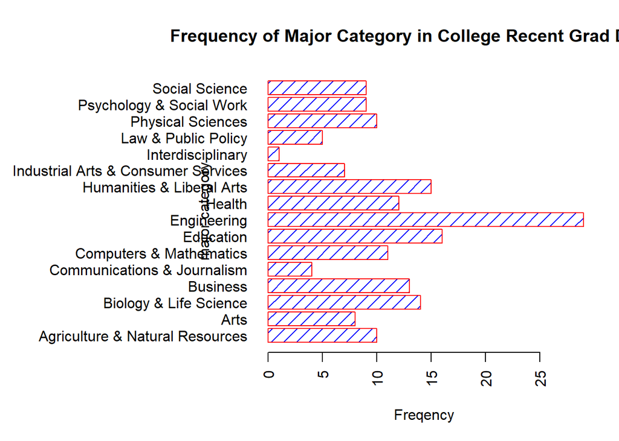

```r
#par(las=2) # rotate label
par(mar=c(5,15,4,2)) # increase y-axis margin.

barplot(major_count,
        main = "Frequency of Major Category in College Recent Grad Dataset",
        ylab = "major category",
        border="red",
        col="blue",
        density=10,
        xlab="Freqency",
        horiz=TRUE,

        las=2,
        )
```

> 4. Write the fivethirtyeight data to a csv file. Make sure that it does not have row labels.

```r
write.csv(df, "grad_Data.csv", row.names=FALSE)
```

# 6. Codebook (30 points):

> 1. Start a new repository on GitHub for your SMU MSDS homework. On your local device, make sure there is a directory for Homework at the minimum; you are welcome to add whatever you would like to this repo in addition to your requirements here.

https://github.com/naivelogic/DDS-MSDS